# Taxonomy match-up

```r
# make sure that no object is in the environment and collect the garbage
rm(list=ls())
gc()
```

```
##           used (Mb) gc trigger (Mb) max used (Mb)
## Ncells  579363   31    1327030 70.9   643734 34.4
## Vcells 1044280    8    8388608 64.0  1649434 12.6
```

```r
# general
library(tidyverse) # data manipulation

# taxonomy
library(worrms)
library(taxize)
library(taxonomyCleanr)
library(algaeClassify)
```

# Introduction

This code outlines **how to clean a list of categories (here mostly phytoplankton) in order to retrieve a valid accepted name for each.**

It is inspired by the recommendations in Neeley et al. (2021) in order to facilitate submission to databases such as SeaBASS or EDI. For the later, a set of functions in base R were developed by Katherine Qi within the EDI-NES-LTER-2019 project ([<https://github.com/klqi/EDI-NES-LTER-2019/tree/master/namespace_validation>](https://github.com/klqi/EDI-NES-LTER-2019/tree/master/namespace_validation)).

The steps presented here use a **tidyverse** structure and are, on purpose, **not turned into functions**. Taxonomy match-up is tricky and I consider that it is better to know exactly which filters are applied on the names and how the data look like at almost every step.

Especially nowadays with imagery devices, categories are not always phytoplankton taxa, they can refer to non-plankton images or morphological categories. It’s easy and fast to manually assign a type - *Morphology, Non-plankton, Taxonomy* - to each category and it makes the work down the line easier. A fourth category, Temporary, can also be used for categories with no identification at all.

The last 3 parts - Morphology, Non-Plankton and Temporary - are thus specifically directed to imagery categories while the Taxonomy part can be used in any setting.

# 1. Data

## A. Initial data

I will be working with an example file containing 37 categories and I will call the initial input category *original_name*. I’m using `read_csv` but if you have latin names, you should export with the base R `read.csv` to properly handle the accents.

```r
data <- read_csv("../data/example_taxo.csv") %>%
  rename(original_name=species)
```

As names change along the way, here is a table describing what each variable name refers to:

| variable | description |
| --- | --- |
| *original_name* | initial input name |
| *name* | cleaned and trimmed name |
| *matched_name2* | names found in databases using `gnr_resolve` |
| *scientificname* | name returned by the taxonomic matching with `wm_records_*` functions |
| *scientificName* | final accepted name |

Once matched to an accepted *scientificName*, we want to create a *scientificNameID* that creates a unique identifier in reference to a database on the model suggested by Neeley et al. (2021):

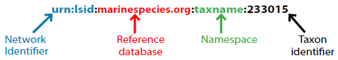

Source: Neeley et al. 2021

## B. Trim the names

A few things are unnecessary for taxonomy match-up and can be removed, mostly using the `trim_taxa` function from the *taxonomyCleanr* package:

- underscores can be replaced by spaces
- extra endings (e.g.: *cf*, *sp, sp.*)
- digits (can often happen in a list from metabarcoding)

```r
data <- data %>%
  # remove all digits
  mutate(name=str_remove_all(original_name,"[:digit:]")) %>%
  # change underscores for spaces and trim endings
  mutate(name = trim_taxa(name))
```

# 2. Taxonomy

## A. Presence in a database

The first thing to try is to see if `gnr_resolve` can resolve the names against a variety of data sources using exact or fuzzy matching.

```r
tax <- filter(data, type=="Taxonomy")
tax
```

```
## # A tibble: 24 x 3
##    original_name              type     name
##    <chr>                      <chr>    <chr>
##  1 Actinocyclus               Taxonomy Actinocyclus
##  2 Asterionellopsis glacialis Taxonomy Asterionellopsis glacialis
##  3 Bacillaria                 Taxonomy Bacillaria
##  4 Baccillaria paxillifer     Taxonomy Baccillaria paxillifer
##  5 Cerataulina bergonii       Taxonomy Cerataulina bergonii
##  6 Chaetoceros elegans        Taxonomy Chaetoceros elegans
##  7 Chaetoceros jonquieri      Taxonomy Chaetoceros jonquieri
##  8 Chaetoceros muellerii      Taxonomy Chaetoceros muellerii
##  9 Chaetoceros_sp12           Taxonomy Chaetoceros
## 10 Ciliophora                 Taxonomy Ciliophora
## # ... with 14 more rows
```

There are 2 advantages of that step:

1. See which species we might have to code by hand
2. Get a name accepted by databases

```r
temp <- gnr_resolve(tax$name, canonical = T,
                    best_match_only = T, preferred_data_sources = c(9,195))

# look at the one(s) for which no match was found
sp_unresolved = setdiff(tax$name, temp$user_supplied_name)
sp_unresolved
```

```
## [1] "Chaetoceros muellerii" "zooplankton"
```

**Attention!** When working with metabarcoding data, some species can be matched up to the genus if the species is unknown from the databases (e.g.: *Chaetoceros jonquieri* here). These species might have never been described morphologically and added to the databases yet. You should always review a taxonomic list at the end.

The list of unresolved species might get longer later if some of the resolved species are not in Worms but I will update it later.

## B. Resolved names

### Retrieve taxonomy from Worms

Now I want to determine if those resolved names (i.e.: the matched names I got from above) I get are found in the Worms database and if they are accepted version or not.

Note : It can happen that the vector of names is too long, in that case, you can just split it in 2 or 3 and resolve each vector. It seems to work best with at most 100 names for `wm_records_names` and 50 names for `wm_records_taxamatch` (see later).

I use the function `wm_records_names` which returns a list, a format unpractical in that case so I use the `map` function from the package `purr` to change it to a tibble. The function allows to precise if we want only marine organisms and to use fuzzy matching or not.

```r
resolved <- wm_records_names(name=unique(temp$matched_name2),marine_only=FALSE) %>%
  map_dfr(as_tibble, .name_repair = "minimal") %>%
  arrange(scientificname)


### Split version
# n <- length(unique(temp$matched_name2))
# resolved <- tibble()
#
# # split the dataset
# for (i in 1:ceiling(n/100)){
#   resworms <- wm_records_names(name=unique(temp$matched_name2)[(100*(i-1)+1):(100*i)], marine_only=FALSE) %>%
#     map_dfr(as_tibble, .name_repair = "minimal")
#   resolved <- bind_rows(resolved,resworms)
```

The results can have one of 4 status:

- **accepted**: the name is the general accepted name and it as been verified/assessed
- **uncertain**: this is the general accepted name but it hasn’t been verified/assessed
- **alternate representation**: it is an accepted name as alternate representation when the species is present with a subgenus or marine/freshwater but not the general accepted name
- **unaccepted**: this is one of the synonyms but not an accepted name

### Duplicates

It’s always good to check for duplicates.

```r
dup <- resolved %>%
  group_by(scientificname) %>%
  filter(n()>1) %>%
  arrange(scientificname)
dup
```

```
## # A tibble: 8 x 27
## # Groups:   scientificname [4]
##   AphiaID url   scientificname authority status unacceptreason taxonRankID rank
##     <int> <chr> <chr>          <chr>     <chr>  <chr>                <int> <chr>
## 1  148944 http~ Actinocyclus   C.G. Ehr~ accep~ <NA>                   180 Genus
## 2  196347 http~ Actinocyclus   Ehrenber~ accep~ <NA>                   180 Genus
## 3  149237 http~ Cerataulina b~ (H.Perag~ unacc~ synonym                220 Spec~
## 4  961694 http~ Cerataulina b~ Ostenfel~ uncer~ unassessed             220 Spec~
## 5  149045 http~ Nitzschia      A.H. Has~ accep~ <NA>                   180 Genus
## 6  119270 http~ Nitzschia      Baer, 18~ accep~ <NA>                   180 Genus
## 7  708005 <NA>  <NA>           <NA>      quara~ <NA>                    NA <NA>
## 8  839793 <NA>  <NA>           <NA>      quara~ unassessed              NA <NA>
## # ... with 19 more variables: valid_AphiaID <int>, valid_name <chr>,
## #   valid_authority <chr>, parentNameUsageID <int>, kingdom <chr>,
## #   phylum <chr>, class <chr>, order <chr>, family <chr>, genus <chr>,
## #   citation <chr>, lsid <chr>, isMarine <int>, isBrackish <int>,
## #   isFreshwater <int>, isTerrestrial <int>, isExtinct <int>, match_type <chr>,
## #   modified <chr>
```

Some can be duplicated:

- who knows why, some records are sometimes fully duplicated: just keep one since they are exactly similar
- remove the ones that do not have a *valid_name*: actually, remove any *valid_name* that’s NA in the dataset that wouldn’t have the status “accepted” or “uncertain” (e.g.: *Kephyriopsis*), they can be dealt with in the unresolved if they were not duplicates (generally disused groups)
- if there is one in the Animalia or Plantae and one in the Chromista kingdom (e.g.: *Actinocyclus*, *Nitzschia*): choose the Chromista as far as it is not supposed to be a zooplankton
- if they have been described twice (e.g.: *Cerataulina bergonii*): then choose the *accepted* or *uncertain* status over the *alternate representation* or *unaccepted* status
- if there is one *accepted* and one *uncertain*: keep the *accepted*
- if there is one marine and one freshwater species (assuming you ran the search with `marine_only=FALSE`): keep the marine one if they have the same lineage (unless you are studying a freshwater station!)
- if they are identical except for the authority choose the oldest/most recent one (just keep consistent)

```r
# remove duplicated rows
resolved <- resolved %>%
  distinct()


# NAs valid_name
filter(resolved, is.na(valid_name))
```

```
## # A tibble: 4 x 27
##   AphiaID url   scientificname authority status unacceptreason taxonRankID rank
##     <int> <chr> <chr>          <chr>     <chr>  <chr>                <int> <chr>
## 1  178600 http~ Coccolithus p~ (Wallich~ uncer~ <NA>                   220 Spec~
## 2  604834 http~ Kephyriopsis   Pascher ~ unacc~ <NA>                   180 Genus
## 3  708005 <NA>  <NA>           <NA>      quara~ <NA>                    NA <NA>
## 4  839793 <NA>  <NA>           <NA>      quara~ unassessed              NA <NA>
## # ... with 19 more variables: valid_AphiaID <int>, valid_name <chr>,
## #   valid_authority <chr>, parentNameUsageID <int>, kingdom <chr>,
## #   phylum <chr>, class <chr>, order <chr>, family <chr>, genus <chr>,
## #   citation <chr>, lsid <chr>, isMarine <int>, isBrackish <int>,
## #   isFreshwater <int>, isTerrestrial <int>, isExtinct <int>, match_type <chr>,
## #   modified <chr>
```

```r
resolved <- resolved %>%
  filter(!(is.na(valid_name) & !(status %in% c("accepted","uncertain"))))


# choose the Chromista over Animalia (or another kingdom like Plantae) if more than 2 occurrences
filter(dup, kingdom!="Chromista")
```

```
## # A tibble: 2 x 27
## # Groups:   scientificname [2]
##   AphiaID url   scientificname authority status unacceptreason taxonRankID rank
##     <int> <chr> <chr>          <chr>     <chr>  <chr>                <int> <chr>
## 1  196347 http~ Actinocyclus   Ehrenber~ accep~ <NA>                   180 Genus
## 2  119270 http~ Nitzschia      Baer, 18~ accep~ <NA>                   180 Genus
## # ... with 19 more variables: valid_AphiaID <int>, valid_name <chr>,
## #   valid_authority <chr>, parentNameUsageID <int>, kingdom <chr>,
## #   phylum <chr>, class <chr>, order <chr>, family <chr>, genus <chr>,
## #   citation <chr>, lsid <chr>, isMarine <int>, isBrackish <int>,
## #   isFreshwater <int>, isTerrestrial <int>, isExtinct <int>, match_type <chr>,
## #   modified <chr>
```

```r
resolved <- resolved %>%
  group_by(scientificname) %>%
  filter(n()==1 | (n() > 1 & kingdom != "Animalia"))


# choose accepted or uncertain status if more than 2 occurrences and one is accepted/uncertain
# (\\b prevents unaccepted to be detected)
resolved <- resolved %>%
  group_by(scientificname) %>%
  filter(n()==1 |
           (n() > 1 & sum(str_detect(status,"\\baccepted|uncertain"))==0) |
           (n() > 1 & sum(str_detect(status,"\\baccepted|uncertain")) > 0) & status %in% c("accepted","uncertain"))


# if there are more than 2 occurrences and one of them is accepted, keep that one
resolved <- resolved %>%
  group_by(scientificname) %>%
  filter(n()==1 |
           (n() > 1 & sum(str_detect(status,"\\baccepted"))==0) |
           (n() > 1 & sum(str_detect(status,"\\baccepted"))>0 &  status == "accepted"))


# if a marine taxon exist, keep the marine taxon (assuming you did your search on both marine and freshwater) if more than 2 occurrences
resolved <- resolved %>%
  group_by(scientificname) %>%
  filter(n()==1 | (n() > 1 & sum(isMarine, na.rm=TRUE) == 0) | (n() > 1 & sum(isMarine, na.rm=TRUE) != 0 & isMarine==1))


# keep the oldest record
resolved <- resolved %>%
  mutate(year=str_split_n(valid_authority,",",2)) %>%
  group_by(scientificname) %>%
  filter(n()==1 | (n() > 1 & year==min(year,na.rm=TRUE)))
```

If a few are left it is probably better to resolve them by hand. You can for instance look at the reference for this taxon in algaeBase. If they both have the same taxonomic lineage, then it is not too much of a difference.

### Others

Now I check if we have a different number of rows between number of taxonomic categories and the number of resolved ones plus unresolved. This will indicate if there are more missing categories than the ones previously identified as unresolved.

```r
# check that you have the correct number of rows: all taxo - non resolved ones
if (nrow(resolved) != (nrow(tax)-length(sp_unresolved))) {
  warning("One or more taxon are missing: either wm_records_names failed for them or they were deleted during the duplicate selection.")
}
```

Keep in mind that `wm_records_names` may fail to find a match for a few species even though `gnr_resolve` found them. These can be treated with the previously unresolved names. It can also retrieve an AlphiaID but no species names if this ID is in quarantine (e.g.: *Leptocylindrus aporus*), these can be removed and dealt with the unresolved ones too.

```r
# remove the ones that are in quarantine = no name was returned
resolved <- filter(resolved, !is.na(scientificname))
```

Also, remember how we removed the ones with no *valid_name* and a status that wasn’t uncertain or accepted? For the others (i.e.: with status accepted/uncertain, e.g.: *Coccolithus pelagicus*), we can just update these with the original scientificname and ID since they were found in Worms and there is no other alternative.

```r
# look if there are any
filter(resolved,is.na(valid_name))
```

```
## # A tibble: 1 x 28
## # Groups:   scientificname [1]
##   AphiaID url   scientificname authority status unacceptreason taxonRankID rank
##     <int> <chr> <chr>          <chr>     <chr>  <chr>                <int> <chr>
## 1  178600 http~ Coccolithus p~ (Wallich~ uncer~ <NA>                   220 Spec~
## # ... with 20 more variables: valid_AphiaID <int>, valid_name <chr>,
## #   valid_authority <chr>, parentNameUsageID <int>, kingdom <chr>,
## #   phylum <chr>, class <chr>, order <chr>, family <chr>, genus <chr>,
## #   citation <chr>, lsid <chr>, isMarine <int>, isBrackish <int>,
## #   isFreshwater <int>, isTerrestrial <int>, isExtinct <int>, match_type <chr>,
## #   modified <chr>, year <chr>
```

```r
# update the valid name and id
resolved <- resolved %>%
  # update the valid name and ID
  mutate(valid_name=ifelse(is.na(valid_name),scientificname,valid_name),
         valid_AphiaID=ifelse(is.na(valid_AphiaID),AphiaID,valid_AphiaID))
```

### Update the species name

So this process returned a *scientifiname* based on the *matched_name2* but I want to keep the name I originally supplied because that’s the one that’s on my main name list so I will add a column a join the two tables.

```r
# join the two tables
resolved <- temp %>%
  select(name=user_supplied_name,scientificname=matched_name2) %>%
  distinct() %>%
  right_join(resolved)

# check that there are no missing values in the name column
if (nrow(filter(resolved,is.na(name))) > 0) {
  warning("The joining process failed for one or more categories")
}
```

## C. Unresolved names

Let’s first update the unresolved categories list.

```r
sp_unresolved <- sort(setdiff(tax$name,resolved$name))
sp_unresolved
```

```
## [1] "Chaetoceros muellerii" "Dinobryon facula"      "Kephyriopsis"
## [4] "Leptocylindrus aporus" "zooplankton"
```

### Retrieve taxonomy from Worms

Now if there are several, you can run functions with fuzzy matching and non-marine species. `wm_records_taxamatch` uses the TAXAMATCH fuzzy matching algorithm and will apply small corrections to the name while `wm_records_names` with fuxxy matching will also return all of the children.

However, since the scientificname will be different from the input name (due to the fuzzy matching) you will have to add an extra column and manually enter the original names if you want to keep track of the original and taxonomically accepted name. Once done, you can evaluate which ones you keep in a similar way as for the resolved species.

Let’s start with `wm_records_taxamatch`.

```r
# TAXAMATCH
 unresolved <- wm_records_taxamatch(sp_unresolved,marine_only = FALSE) %>%
  map_dfr(as_tibble, .name_repair = "minimal")
```

Now we can look at which ones were not exact match and update their name. We are thus keeping the exact matches and the updated names ones. Again, we might have some quarantined returning NAs so these will be removed.

```r
# non-exact match type
filter(unresolved, match_type!="exact")
```

```
## # A tibble: 1 x 27
##   AphiaID url   scientificname authority status unacceptreason taxonRankID rank
##     <int> <chr> <chr>          <chr>     <chr>  <chr>                <int> <chr>
## 1  163098 http~ Chaetoceros m~ Lemmerma~ accep~ <NA>                   220 Spec~
## # ... with 19 more variables: valid_AphiaID <int>, valid_name <chr>,
## #   valid_authority <chr>, parentNameUsageID <int>, kingdom <chr>,
## #   phylum <chr>, class <chr>, order <chr>, family <chr>, genus <chr>,
## #   citation <chr>, lsid <chr>, isMarine <int>, isBrackish <lgl>,
## #   isFreshwater <int>, isTerrestrial <int>, isExtinct <int>, match_type <chr>,
## #   modified <chr>
```

```r
# add the original name
unresolved <- unresolved %>%
  # update the wrong ones (can also use str_detect)
  mutate(name = case_when(match_type=="exact"~scientificname,
                          scientificname=="Chaetoceros muelleri"~"Chaetoceros muellerii",
                          TRUE ~ NA_character_)) %>%
  # remove the ones that returned NA (quarantined)
  filter(!is.na(name))
```

### Duplicates

Next thing is to check for duplicates (see section B) check if there are duplicates, run a few filters as seen for the resolved names and check again for duplicates before adding to the resolved table.

```r
dup <- unresolved %>%
  group_by(scientificname) %>%
  filter(n()>1) %>%
  arrange(scientificname)
dup
```

```
## # A tibble: 0 x 28
## # Groups:   scientificname [0]
## # ... with 28 variables: AphiaID <int>, url <chr>, scientificname <chr>,
## #   authority <chr>, status <chr>, unacceptreason <chr>, taxonRankID <int>,
## #   rank <chr>, valid_AphiaID <int>, valid_name <chr>, valid_authority <chr>,
## #   parentNameUsageID <int>, kingdom <chr>, phylum <chr>, class <chr>,
## #   order <chr>, family <chr>, genus <chr>, citation <chr>, lsid <chr>,
## #   isMarine <int>, isBrackish <lgl>, isFreshwater <int>, isTerrestrial <int>,
## #   isExtinct <int>, match_type <chr>, modified <chr>, name <chr>
```

Here we have none!

### Others

In this case, there are no duplicates but we want to check that we have valid names (same as for the resolved ones) and, in the case they are NA, update their name if their status is accepted.

```r
# remove NA valid_name when status is not accepted/uncertain
filter(unresolved, is.na(valid_name))
```

```
## # A tibble: 1 x 28
##   AphiaID url   scientificname authority status unacceptreason taxonRankID rank
##     <int> <chr> <chr>          <chr>     <chr>  <chr>                <int> <chr>
## 1  604834 http~ Kephyriopsis   Pascher ~ unacc~ <NA>                   180 Genus
## # ... with 20 more variables: valid_AphiaID <int>, valid_name <chr>,
## #   valid_authority <chr>, parentNameUsageID <int>, kingdom <chr>,
## #   phylum <chr>, class <chr>, order <chr>, family <chr>, genus <chr>,
## #   citation <chr>, lsid <chr>, isMarine <int>, isBrackish <lgl>,
## #   isFreshwater <int>, isTerrestrial <int>, isExtinct <int>, match_type <chr>,
## #   modified <chr>, name <chr>
```

```r
unresolved <- unresolved %>%
  filter(!(is.na(valid_name) & !(status %in% c("accepted","uncertain"))))

# NAs valid name with status accepted/uncertain?
filter(unresolved, is.na(valid_name))
```

```
## # A tibble: 0 x 28
## # ... with 28 variables: AphiaID <int>, url <chr>, scientificname <chr>,
## #   authority <chr>, status <chr>, unacceptreason <chr>, taxonRankID <int>,
## #   rank <chr>, valid_AphiaID <int>, valid_name <chr>, valid_authority <chr>,
## #   parentNameUsageID <int>, kingdom <chr>, phylum <chr>, class <chr>,
## #   order <chr>, family <chr>, genus <chr>, citation <chr>, lsid <chr>,
## #   isMarine <int>, isBrackish <lgl>, isFreshwater <int>, isTerrestrial <int>,
## #   isExtinct <int>, match_type <chr>, modified <chr>, name <chr>
```

```r
# update the valid name and id
unresolved <- unresolved %>%
  # update the valid name and ID
  mutate(valid_name=ifelse(is.na(valid_name),scientificname,valid_name),
         valid_AphiaID=ifelse(is.na(valid_AphiaID),AphiaID,valid_AphiaID))
```

The last step checks if there are some left:

```r
if (nrow(unresolved) < length(sp_unresolved)) {
  warning("There are still categories unresolved.")
}
```

### Hard code the others

These are harder to determine. They may be due to more general categories or common names. You can try to run the function `get_wormsid` indicating `searchtype="common"` or `wm_records_names` with `fuzzy=TRUE` but you will likely have to hard code them and it’s also faster if you have only a few of them.

```r
sp_unresolved[!(sp_unresolved %in% unresolved$name)]
```

```
## [1] "Dinobryon facula"      "Kephyriopsis"          "Leptocylindrus aporus"
## [4] "zooplankton"
```

I can check first if they appear in any database, that can give an indication of what the name could be.

```r
gnr_resolve(sp_unresolved[!(sp_unresolved %in% unresolved$name)])
```

```
## # A tibble: 22 x 5
##    user_supplied_name submitted_name   matched_name   data_source_title    score
##  * <chr>              <chr>            <chr>          <chr>                <dbl>
##  1 Dinobryon facula   Dinobryon facula Dinobryon fac~ Encyclopedia of Life 0.988
##  2 Dinobryon facula   Dinobryon facula Dinobryon fac~ Open Tree of Life R~ 0.988
##  3 Dinobryon facula   Dinobryon facula Dinobryon fac~ The Interim Registe~ 0.988
##  4 Dinobryon facula   Dinobryon facula Dinobryon fac~ GBIF Backbone Taxon~ 0.988
##  5 Dinobryon facula   Dinobryon facula Dinobryon fac~ AlgaeBase            0.988
##  6 Kephyriopsis       Kephyriopsis     Kephyriopsis   Wikispecies          0.75
##  7 Kephyriopsis       Kephyriopsis     Kephyriopsis   Integrated Taxonomi~ 0.75
##  8 Kephyriopsis       Kephyriopsis     Kephyriopsis   GBIF Backbone Taxon~ 0.75
##  9 Kephyriopsis       Kephyriopsis     Kephyriopsis   Encyclopedia of Life 0.75
## 10 Kephyriopsis       Kephyriopsis     Kephyriopsis   uBio NameBank        0.75
## # ... with 12 more rows
```

In this case, I still have 4 unresolved ones:

- *zooplankton* which I will match to *Animalia*
- *Leptocylindrus aporus*: in algaeBase it corresponds to *Leptocylindrus danicus var. aporus* which is in quarantine in Worms so I’ll just code it as *Leptocylindrus danicus*. Another solution, especially if you have several missing ones in Worms but present in AlgaeBase (most likely freshwater algae) is to hard code them with the id from AlgaeBase (see the optional next point)
- *Dinobryon facula*: it is in algaeBase but not in Worms so to retain the taxonomy I’ll code it at the end of this section 2 with the algaeBase ID
- *Kephyriopsis*: it is unaccepted but there are no accepted genus corresponding to it and some accepted species still have that genus so I will keep it and update its *valid_name* and *valid_AphiaID* since they were missing

```r
# get the taxonomy for the updated names
unresolved_manual <- wm_records_names(c("Leptocylindrus danicus","Animalia","Kephyriopsis"), marine_only = FALSE) %>%
  map_dfr(as_tibble, .name_repair = "minimal")


# add the initial name
unresolved_manual <- unresolved_manual %>%
  # add a column with the name
  mutate(name = case_when(str_detect(scientificname,"danicus")~"Leptocylindrus aporus",
                          scientificname=="Animalia"~"zooplankton",
                          TRUE ~ scientificname))
```

Same as before, we need to check for duplicates and handle them and the NA *valid_name*. Here there is one, *Leptocylindrus danicus* for which the only difference is the authority so I will keep the oldest record.

```r
# duplicates?
dup <- unresolved_manual %>%
  group_by(scientificname) %>%
  filter(n()>1) %>%
  arrange(scientificname)
dup
```

```
## # A tibble: 2 x 28
## # Groups:   scientificname [1]
##   AphiaID url   scientificname authority status unacceptreason taxonRankID rank
##     <int> <chr> <chr>          <chr>     <chr>  <chr>                <int> <chr>
## 1  149106 http~ Leptocylindru~ Cleve, 1~ uncer~ unassessed             220 Spec~
## 2  962746 http~ Leptocylindru~ Schutt, ~ uncer~ unassessed             220 Spec~
## # ... with 20 more variables: valid_AphiaID <int>, valid_name <chr>,
## #   valid_authority <chr>, parentNameUsageID <int>, kingdom <chr>,
## #   phylum <chr>, class <chr>, order <chr>, family <chr>, genus <chr>,
## #   citation <chr>, lsid <chr>, isMarine <int>, isBrackish <int>,
## #   isFreshwater <int>, isTerrestrial <int>, isExtinct <lgl>, match_type <chr>,
## #   modified <chr>, name <chr>
```

```r
# keep the oldest record
unresolved_manual <- unresolved_manual %>%
  mutate(year=str_split_n(valid_authority,",",2)) %>%
  group_by(scientificname) %>%
  filter(n()==1 | (n() > 1 & year==min(year,na.rm=TRUE)))
# update NA for Kephyriopsis (could change based on your decision)
filter(unresolved_manual,is.na(valid_name))
```

```
## # A tibble: 1 x 29
## # Groups:   scientificname [1]
##   AphiaID url   scientificname authority status unacceptreason taxonRankID rank
##     <int> <chr> <chr>          <chr>     <chr>  <chr>                <int> <chr>
## 1  604834 http~ Kephyriopsis   Pascher ~ unacc~ <NA>                   180 Genus
## # ... with 21 more variables: valid_AphiaID <int>, valid_name <chr>,
## #   valid_authority <chr>, parentNameUsageID <int>, kingdom <chr>,
## #   phylum <chr>, class <chr>, order <chr>, family <chr>, genus <chr>,
## #   citation <chr>, lsid <chr>, isMarine <int>, isBrackish <int>,
## #   isFreshwater <int>, isTerrestrial <int>, isExtinct <lgl>, match_type <chr>,
## #   modified <chr>, name <chr>, year <chr>
```

```r
unresolved_manual <- unresolved_manual %>%
  # update the valid name and ID
  mutate(valid_name=ifelse(is.na(valid_name),scientificname,valid_name),
         valid_AphiaID=ifelse(is.na(valid_AphiaID),AphiaID,valid_AphiaID))
```

## D. Combine and extract LSID

### Combine the tables

I can combine all of the tables and check that there is the same number of taxon that in the original tax table.

```r
taxres <- bind_rows(resolved,unresolved,unresolved_manual)

if (!(is_empty(setdiff(tax$name,taxres$name)))) {
  warning("There are missing categories between the original list and the resolved one.")
}
```

Here I have one missing species, the one that’s in algaeBase but not Worms. Because I’ll need to create the look up the details, I’ll update it at the end.

```r
setdiff(tax$name,taxres$name)
```

```
## [1] "Dinobryon facula"
```

### Update species and LSID for the accepted ones

The function `wm_records_names` also return the accepted names (valid_name) and corresponding AphiaID (valid_AphiaID) for each taxon. I can thus swap out these.

The *alternate representation* is tricky because it sometimes swap out a marine associated name for a freshwater associated one. However, for the sake of matching databases and taxonomic lists, it is easier to have a common accepted name between the databases. The original name will, anyway, stay in the table for reference.

```r
taxres <- taxres %>%
  # rename the valid name as scientificName
  rename(scientificName = valid_name)
```

### Retrieve the LSID

The LSID is constructed using the AphiaID, the specific taxon id of Worms.

The AphiaIDs corresponding the valid taxon names are already retrieved by `wm_records_names` and stored in the *valid_AphiaID* column.

The LSID for the matched taxon is also retrieved so all we have to do is change the taxon ID in it for the valid one. For that, we get the three first component of the lsid and paste the valid AphiaID with them. Here, they are all from Worms so we could also directly write *“urn:lsid:marinespecies.org:taxname”* instead of splitting the original lsid.

```r
taxres <- taxres %>%
  mutate(scientificNameID=paste(str_split_n(lsid,":[0-9]",n=1), valid_AphiaID, sep=":"))
```

### Build the taxonomy table

We can add all of that into a table.

```r
# join with the table with the original names
tax <- taxres %>%
  select(name,rank,scientificName,scientificNameID,kingdom) %>%
  right_join(tax)

# clean variables
rm(dup,resolved,taxres,temp,unresolved,unresolved_manual,sp_unresolved)
```

### (optional) Add the missing species from algaeBase

It can happen that very specific species or varieties are not recorded in Worms but are in algaeBase. There is no equivalent (that I know of) of `wm_records_names` for algaeBase except for `algae_search` from the *algaeClassify* package but it only returns NAs for the species I’ve tried so it is mostly useful in checking if the species exist or not in algaeBase.

This is obviously a non-necessary step if you have resolved all of your species before. In general I have species level categories in the Chromista kingdom so I find it easier to assign that to all and update the few that might be wrong.

```r
# prepare the tibble
algae <- tibble(name=c("Dinobryon facula"),
           rank="Species",
           scientificName=name,
           kingdom="Chromista",
           original_name=name,
           type="Taxonomy")
    ## update the rank/kingdom for the specific ones
    # mutate(rank=ifelse(str_detect(name,"var."),"Variety",rank))


# add the scientificnameID
algae$scientificNameID <- paste0("urn:lsid:algaebase.org:taxname:",
                                c(143479))


# check that they are correct
algaebase <- spp_list_algaebase(algae,"name")
```

```
## 0% completed
```

```r
if (sum(algaebase$name!=algae$name)>0) {
  warning("There seems to be a mistake in the algaeBase IDs.")
}


# remove them from the tax list and add the updated ones
tax <- filter(tax, !(original_name %in% algae$original_name))
tax <- bind_rows(tax, algae) %>% arrange(scientificName)
```

# 3. Morphology

## A. Hard code the names

These are more complex groups as they need to be coded at the lowest possible taxonomy but generally will need to be coded by hand. I’m showing here a few examples from our own datasets but it will depend on the naming convention of each lab.

```r
morpho <- data %>%
  filter(type == "Morphology")
morpho
```

```
## # A tibble: 7 x 3
##   original_name           type       name
##   <chr>                   <chr>      <chr>
## 1 Euglenophyceae long     Morphology Euglenophyceae long
## 2 group chaetoceros curly Morphology group chaetoceros curly
## 3 group pennate           Morphology group pennate
## 4 Protozoa pointy         Morphology Protozoa pointy
## 5 Protozoa square         Morphology Protozoa square
## 6 Strombidium morphotype1 Morphology Strombidium morphotype
## 7 Thalassiosira chain     Morphology Thalassiosira chain
```

In our database and classifier, we group some of the classes within the algorithm and those classes start with the prefix *group* (e.g.: *group pennate*) while the rest of the morphological variables are coded by the class followed by the morphological characteristic (e.g.: *Thalassiosira chain*).

An ifelse statement allows me to keep only the second part of a name if it starts with group and only the first part if it doesn’t.

```r
morpho <- morpho %>%
  mutate(scientificname = ifelse(str_split_n(name," ",n=1)=="group",
                                 str_split_n(name," ",n=2),
                                 str_split_n(name," ",n=1)))
morpho
```

```
## # A tibble: 7 x 4
##   original_name           type       name                    scientificname
##   <chr>                   <chr>      <chr>                   <chr>
## 1 Euglenophyceae long     Morphology Euglenophyceae long     Euglenophyceae
## 2 group chaetoceros curly Morphology group chaetoceros curly chaetoceros
## 3 group pennate           Morphology group pennate           pennate
## 4 Protozoa pointy         Morphology Protozoa pointy         Protozoa
## 5 Protozoa square         Morphology Protozoa square         Protozoa
## 6 Strombidium morphotype1 Morphology Strombidium morphotype  Strombidium
## 7 Thalassiosira chain     Morphology Thalassiosira chain     Thalassiosira
```

The only one right now that is not scientific is *pennate* so I can manually hard code that one and make sure that all have an uppercase at the beginning.

```r
morpho <- morpho %>%
  mutate(scientificname = replace(scientificname,
                                  scientificname=="pennate",
                                  "Bacillariophycidae")) %>%
  mutate(scientificname = str_to_sentence(scientificname))
morpho
```

```
## # A tibble: 7 x 4
##   original_name           type       name                    scientificname
##   <chr>                   <chr>      <chr>                   <chr>
## 1 Euglenophyceae long     Morphology Euglenophyceae long     Euglenophyceae
## 2 group chaetoceros curly Morphology group chaetoceros curly Chaetoceros
## 3 group pennate           Morphology group pennate           Bacillariophycidae
## 4 Protozoa pointy         Morphology Protozoa pointy         Protozoa
## 5 Protozoa square         Morphology Protozoa square         Protozoa
## 6 Strombidium morphotype1 Morphology Strombidium morphotype  Strombidium
## 7 Thalassiosira chain     Morphology Thalassiosira chain     Thalassiosira
```

## B. Retrieve the taxonomy and update LSID

### Worms taxonomy

Same as before, I run these in Worms, check that there are no duplicates and update the name and the LSID. Here we are 2 duplicates because we have 2 Protozoa categories so they are identical and once can be deleted.

```r
# get the worms id corresponding to it
morphres <- wm_records_names(morpho$scientificname, marine_only = FALSE) %>%
  map_dfr(as_tibble, .name_repair = "minimal")


# duplicates?
dup <- morphres %>%
  group_by(scientificname) %>%
  filter(n()>1) %>%
  arrange(scientificname)
dup
```

```
## # A tibble: 2 x 27
## # Groups:   scientificname [1]
##   AphiaID url   scientificname authority status unacceptreason taxonRankID rank
##     <int> <chr> <chr>          <chr>     <chr>  <lgl>                <int> <chr>
## 1       5 http~ Protozoa       Owen, 18~ accep~ NA                      10 King~
## 2       5 http~ Protozoa       Owen, 18~ accep~ NA                      10 King~
## # ... with 19 more variables: valid_AphiaID <int>, valid_name <chr>,
## #   valid_authority <chr>, parentNameUsageID <int>, kingdom <chr>,
## #   phylum <chr>, class <chr>, order <chr>, family <chr>, genus <chr>,
## #   citation <chr>, lsid <chr>, isMarine <int>, isBrackish <int>,
## #   isFreshwater <int>, isTerrestrial <int>, isExtinct <int>, match_type <chr>,
## #   modified <chr>
```

### Update name and LSID

```r
# delete extra line and update name and LSID
morphres <- morphres %>%
  # delete duplicate
  distinct() %>%
  # rename the valid_name columns
  rename(scientificName = valid_name) %>%
  # update the LSID
  mutate(scientificNameID=paste(str_split_n(lsid,":[0-9]",n=1), valid_AphiaID, sep=":"))
```

### Combine table

First, let’s make sure that there are the same categories in both the resolved and original tables.

```r
if (!(is_empty(setdiff(morpho$scientificname,morphres$scientificname)))) {
  warning("There are missing categories between the original list and the resolved one.")
}
```

The only step left is to create a similar table as the one we had for taxonomy:

```r
# create table
morpho <- morphres %>%
  select(scientificname,rank,scientificName, scientificNameID,kingdom) %>%
  right_join(morpho) %>%
  select(-scientificname)

# remove variables
rm(dup,morphres)
```

# 4. Non-plankton

These can still be living things but they are unrelated to plankton.

```r
nl <- filter(data, type=="Non-plankton")
nl
```

```
## # A tibble: 5 x 3
##   original_name type         name
##   <chr>         <chr>        <chr>
## 1 bubble part   Non-plankton bubble part
## 2 detritus      Non-plankton detritus
## 3 pollen        Non-plankton pollen
## 4 unclassified  Non-plankton unclassified
## 5 other         Non-plankton other
```

They can be classified *via* the Phytoplankton Taxonomy Working Group namespace (https://seabass.gsfc.nasa.gov/wiki/plankton_and_particles) using:

- scientificName = -9999
- scientificNameID = “ptwg:name” (one of ‘bad_image’, ‘bead’, ‘bubble’, ‘detritus’,"fecal_pellet’, and ‘other’)

```r
nl <- nl %>%
  mutate(scientificName = as.character(-9999),
      scientificNameID = case_when(str_detect(name,"bubble") ~ "ptwg:bubble",
                              str_detect(name,"detritus") ~ "ptwg:detritus",
                              str_detect(name,"other|unclassified") ~ "ptwg:other",
                              TRUE ~ NA_character_),
      rank = NA_character_,
      kingdom=NA_character_)
nl
```

```
## # A tibble: 5 x 7
##   original_name type         name  scientificName scientificNameID rank  kingdom
##   <chr>         <chr>        <chr> <chr>          <chr>            <chr> <chr>
## 1 bubble part   Non-plankton bubb~ -9999          ptwg:bubble      <NA>  <NA>
## 2 detritus      Non-plankton detr~ -9999          ptwg:detritus    <NA>  <NA>
## 3 pollen        Non-plankton poll~ -9999          <NA>             <NA>  <NA>
## 4 unclassified  Non-plankton uncl~ -9999          ptwg:other       <NA>  <NA>
## 5 other         Non-plankton other -9999          ptwg:other       <NA>  <NA>
```

However, not all of them are defined within this namespace and each lab might have some specific ones. Within the **mouwlab** namespace for instance, I will define one more: ‘pollen’

```r
nl <- nl %>%
  mutate(scientificNameID = case_when(str_detect(name,"pollen") ~ "mouwlab:pollen",
                                      TRUE ~ scientificNameID))
nl
```

```
## # A tibble: 5 x 7
##   original_name type         name  scientificName scientificNameID rank  kingdom
##   <chr>         <chr>        <chr> <chr>          <chr>            <chr> <chr>
## 1 bubble part   Non-plankton bubb~ -9999          ptwg:bubble      <NA>  <NA>
## 2 detritus      Non-plankton detr~ -9999          ptwg:detritus    <NA>  <NA>
## 3 pollen        Non-plankton poll~ -9999          mouwlab:pollen   <NA>  <NA>
## 4 unclassified  Non-plankton uncl~ -9999          ptwg:other       <NA>  <NA>
## 5 other         Non-plankton other -9999          ptwg:other       <NA>  <NA>
```

The last step is just to check that there are no missing *scientificNameID*:

```r
if (nrow(filter(nl, is.na(scientificNameID))) > 0) {
  warning("Not all scientificNameID have been assigned: you need to define more categories in the namespace")
}
```

# 5. Temporary

These classes have not been associated with any classification. However, they are usually living things so they could be associated to *Eukaryota*.

You should check if this is the case for yours.

```r
temp <- data %>%
  filter(type == "Temporary") %>%
  mutate(scientificName="Eukaryota",
         scientificNameID="urn:lsid:algaebase.org:taxname:86701",
         rank=NA_character_)
temp
```

```
## # A tibble: 1 x 6
##   original_name type      name  scientificName scientificNameID            rank
##   <chr>         <chr>     <chr> <chr>          <chr>                       <chr>
## 1 t001          Temporary t     Eukaryota      urn:lsid:algaebase.org:tax~ <NA>
```

# 6. Combining and exporting

We can combine our different tables and check that we haven’t forgotten any categories…

```r
# combine tables
data_matched <- bind_rows(tax,morpho,nl,temp)

# check that there is the same number of rows with the original data and the same categories
if (nrow(data) != nrow(data_matched) |
    !(is_empty(setdiff(data$name,data_matched$name)))) {
  warning("You've forgotten or added a category along the way...")
}
```

What can happen is that the `gnr_resolve` function has a little bit of fuzzy matching and might match the name to several *matched_names2*. That’s the case here for *Baccillaria paxillifer* which got matched to both *paxillifer* and *paxillifera*. You can detect it by looking if any rows are fully duplicated:

```r
filter(data_matched, duplicated(data_matched))
```

```
## # A tibble: 1 x 7
##   name    rank   scientificName  scientificNameID   kingdom original_name  type
##   <chr>   <chr>  <chr>           <chr>              <chr>   <chr>          <chr>
## 1 Baccil~ Speci~ Vibrio paxilli~ urn:lsid:marinesp~ Chromi~ Baccillaria p~ Taxo~
```

That’s the case here for one species so we can use the `distinct` function to remove it:

```r
data_matched <- distinct(data_matched)
```

Review! It’s very important to scan your table to make sure there are no mistakes. Look for:

- simplifications from species to genus => are they justified? is it because the species only have metabarcoding?
- species in the kingdom animalia => is the classification correct?
- NAs?

Lastly, we can export our matched table. I’m using `write_csv` but if you have latin names, you should export with the base R `write.csv` to properly handle the accents.

```r
# export as csv
write_csv(data_matched,"../data/matched_example_taxo.csv")
```